# An R toolkit to simplify and automate an open scientific workflow

## Why have a toolkit for open science workflows?

[figure not shown]

"Scratch" image from [PhD Comics](http://phdcomics.com/comics/archive_print.php?comicid=1689), 3/12/2014

## Demand for more open science is increasing

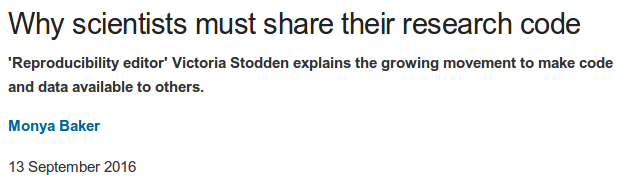

From Nature News

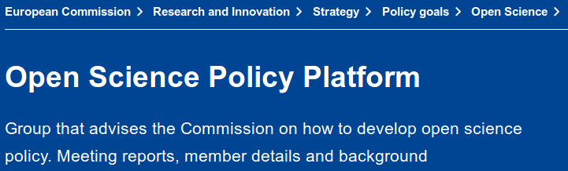

From https://ec.europa.eu/research/openscience

## Current available R packages/workflows

- rrtools
- [ProjectTemplate](http://projecttemplate.net/)
- makeProject
- devtools, usethis directly

## … Just another competing package?

[figure not shown]

Image from: https://xkcd.com/927/

## … Probably. But, there are still things missing or not addressed

- Fairly complicated
- Assume complex analyses
- Don't automate enough
- Not targeted to "casual coders"
  - e.g. most health researchers
- Are not opinionated enough
  - "Here are options and a general workflow, you decide the rest"

## What is needed and why?

- Lots of support and guidance
  - Many (health) researchers *don't know* about open science
  - …Or *how to do it*
- Opinionated on what services and tools to use
  - Many tools and "moving parts"… it's *overwhelming*
- Automation of most tasks, rather than through documentation
  - *Default* for open science should be *easy*

## Enter the [prodigenr](http://prodigenr.lukewjohnston.com/) package

[figure not shown]

## Main function…

Generate project directory, `setup_project()`:

```
.
├── R
│   ├── README.md
│   ├── fetch_data.R
│   └── setup.R
├── data
│   └── README.md
├── doc
│   └── README.md
├── .Rbuildignore
├── .gitignore
├── DESCRIPTION
├── ProjectName.Rproj
└── README.md
```

## … similar structure to R packages

Advantages:

- Established infrastructure
- Well developed through devtools, usethis
- Handles range in project difficulty
  - (simple to complex analyses)

## Some of the other functions:

Add scientific product, e.g. poster, `create_poster()`:

```
.
├── R
│   ├── README.md
│   ├── fetch_data.R
│   └── setup.R
├── data
│   └── README.md
├── doc
│   ├── README.md
│   └── poster.Rmd
├── .Rbuildignore
├── .gitignore
├── DESCRIPTION
├── ProjectName.Rproj
└── README.md
```

## Other functions:

- Add author(s) to project metadata (=DESCRIPTION file):
  - `add_first_author()`
  - `add_coauthor()`
- Include some common "tools":
  - `include_mit_license()` for code
  - `include_strobe()` for health research reporting

## Current stage of development

- Participating in [Mozilla Open Project Leader Training](https://mozilla.github.io/leadership-training/round-5/projects/#an-r-software-toolkit-to-simplify-an-open-collaborative-scientif)
- Participated in [Mozilla Global Sprint](https://github.com/mozilla/global-sprint/issues/152)
  - Gained some feedback
- Soon submit next version to CRAN

## Next steps and future plans

- Focus prodigenr on project generation
- Tag/version bump after e.g. manuscript submission
- Reproducibility tools (e.g. travis, docker)
- Other functionality to new package, rostools
- Teaching material and more docs

## How does this help?

- Open science is evolving
  - This automates and bundles together common tools
  - (of course, strongly opinionated on which tools)
- Natural extension to the devtools/usethis framework
- Researchers need easy tools
  - *This one of the first steps* toward that

## Reason for this talk…

- Looking for feedback, thoughts, comments
- But mostly… seeking potential contributors/collaborators!
- **Contact info**
  - GitHub: [`@lwjohnst86`](https://github.com/lwjohnst86)
  - Email: lwjohnst@ph.au.dk
  - Slides: https://github.com/lwjohnst86/erum2018

[figure not shown]

[figure not shown]

Licensed under a [CC-BY 4.0 International License](http://creativecommons.org/licenses/by/4.0/).